# Assignment 3

Alex Khaykin

2023-10-04

```r
library(RSocrata)
library(tidyverse)
library(tidyr)
library(dplyr)
```

## INTRODUCTION

It is an open question whether tighter gun regulation lead to consistently reduced mortality rates due to firearms in the Unite States. To answer the question “Do stricter firearm control laws help reduce firearm mortality?”, I will compare the average firearm mortality rates as recorded by the CDC to the number of gun laws on the books instituted in each state. I will be using the Socrata API to download it CDC mortality data for 2020 through 2022and filtered for just firearm related causes of death or injury.Further, I removed the annual moving averages from the dataset.I also filter for the age adjusted mortality rate.Nest I split the year_and_quarter column into two columns, year and quarter. I dropped the other rate categories except the national and state level rates of mortality.

```r
firearm_cdc <- read.socrata("https://data.cdc.gov/d/489q-934x")
firearm_cdc <- firearm_cdc %>%
  filter(cause_of_death == "Firearm-related injury", time_period == "3-month period", rate_type == "Age-adjusted")
firearm_cdc <- firearm_cdc %>%
  separate(year_and_quarter, c("year", "quarter"))
firearm_cdc <- firearm_cdc[,c(1,2,20:70)]
```

The data was in wide format, I decided to pivot it longer.

```r
firearm_cdc_long <- firearm_cdc %>%
  pivot_longer(cols = starts_with("rate"), names_to = "state", values_to = "rate", names_prefix = "rate_")
firearm_cdc_long %>%
  head()
```

```
## # A tibble: 6 × 4
##   year  quarter state       rate
##   <chr> <chr>   <chr>      <dbl>
## 1 2020  Q1      alaska      21.4
## 2 2020  Q1      alabama     23
## 3 2020  Q1      arkansas    20.8
## 4 2020  Q1      arizona     15.9
## 5 2020  Q1      california   7.5
## 6 2020  Q1      colorado    14.2
```

I obtained state firearm laws database from the national archive of criminal justice data from the university of Michigan, which spans from 1991-2019.

```r
load("C:\\Users\\akhay\\OneDrive\\Documents\\DATA_SCIENCE\\DATA_608\\Major Assignments\\Assignment_3\\data\\37363-0001-Data.rda")
law <- da37363.0001
#str(law)
```

In order to be objective, I will simply tally up the amount of gun laws on the books per state to arrive at a summed up total. I also filtered the data for only 2019 because that is the first year preceding the years of mortality data.

```r
law <- law %>%
  filter(YEAR == 2019) %>%
  mutate_if(is.factor, as.character) %>%
  mutate(across(.cols = 3:137, ~ case_when(.=="(0) Law provision is not present" ~ 0,
                                           .=="(1) Law provision is present" ~ 1))) %>%
  mutate(total_laws = rowSums(.[3:137], na.rm=TRUE))
  law %>%
    head()
```

```
##            STATE YEAR FELONY INVCOMMITMENT INVOUTPATIENT DANGER DRUGMISDEMEANOR
## 1 Alabama        2019      0             1             0      1               0
## 2 Alaska         2019      1             0             0      0               0
## 3 Arizona        2019      1             1             1      1               0
## 4 Arkansas       2019      1             1             0      1               0
## 5 California     2019      1             1             0      1               0
## 6 Colorado       2019      1             0             0      0               0
##   ALCTREATMENT ALCOHOLISM RELINQUISHMENT VIOLENT VIOLENTH VIOLENTPARTIAL DEALER
## 1            0          1              0       0        0              0      0
## 2            0          0              0       0        0              0      0
## 3            0          0              0       0        0              0      0
## 4            0          0              0       0        0              0      0
## 5            0          1              1       1        1              1      1
## 6            0          0              0       0        0              0      0
##   DEALERH RECORDSALL RECORDSALLH RECORDSDEALER RECORDSDEALERH REPORTALL
```

[output cut: 160 more lines]

I will use quintiles to determine the cutoffs for a the five point Likert scale.

```r
quantile(law$total_laws, c(.2, .4, .6, .8))
```

```
##  20%  40%  60%  80%
##  7.8 14.2 21.4 41.2
```

The cutoffs that I have determined are: * 1 = less than 7.8 * 2 = 7.8 to 14.19999 * 3 = 14.2 to 21.3999 * 4 = 21.4 to 41.1999 * 5 = greater than 41.2

```r
law2 <- law %>%
  select(STATE, total_laws) %>%
  mutate(Likert = case_when(total_laws < 7.8 ~ 1,
                            total_laws <14.2 ~ 2,
                            total_laws < 21.4 ~ 3,
                            total_laws < 41.2 ~ 4,
                            total_laws >= 41.2 ~5))
```

To join the two datasets, which are the firearm mortality dataset and state laws dataset.

```r
law3 <- law2 %>%
  mutate(STATE = toupper(STATE)) %>%
  mutate(STATE = gsub(" ", "", STATE))

firearm_cdc_long2 <- firearm_cdc_long %>%
  mutate(STATE = toupper(state)) %>%
  mutate(STATE = gsub("_", "", STATE)) %>%
  select(-state) %>%
  group_by(STATE) %>%
  summarise(rate = mean(rate, na.rm = TRUE))

dat <- inner_join(law3, firearm_cdc_long2, by = "STATE")
```

To create a heat map.

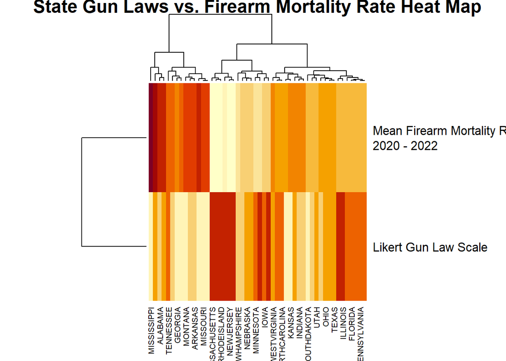

```r
mat <- as.matrix(dat[,3:4])

heatmap(t(mat), labCol = dat$STATE, labRow = c("Likert Gun Law Scale", "Mean Firearm Mortality Rate \n2020 - 2022"), cexRow = 1.25, main = "State Gun Laws vs. Firearm Mortality Rate Heat Map")
```

## CONCLUSION

Do stricter firearm control laws help reduce firearm mortality? To conclude it does appear that there is a negative correlation which points to a negative relationship between the higher rated gun law states and a lower firearm related average mortality rates in some state. Such as within the cluster including Massachusetts, Rode Island, and New Jersey, however, that is not the case across the board in all states, such is within the cluster including Texas, Illinois, Florida, and Pennsylvania. In the later cluster the relationship seems less significant where the gun laws enacted are higher rated but do not result in a much lower firearm related average mortality rate. Future work to explore this relationship may include other variables such a poverty and employment rates, as well as a better visualization to show a clearer relationship or lack there off.